# W3cubDocs

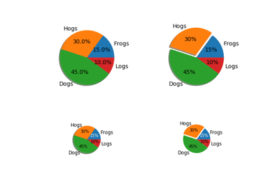

[Pie Demo2](https://matplotlib.org/3.1.1/gallery/pie_and_polar_charts/pie_demo2.html#sphx-glr-gallery-pie-and-polar-charts-pie-demo2-py)

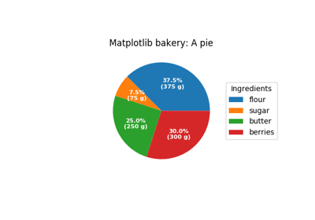

[Labeling a pie and a donut](https://matplotlib.org/3.1.1/gallery/pie_and_polar_charts/pie_and_donut_labels.html#sphx-glr-gallery-pie-and-polar-charts-pie-and-donut-labels-py)

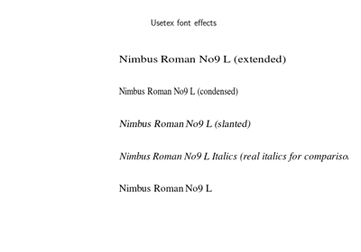

[Usetex Fonteffects](https://matplotlib.org/3.1.1/gallery/text_labels_and_annotations/usetex_fonteffects.html#sphx-glr-gallery-text-labels-and-annotations-usetex-fonteffects-py)

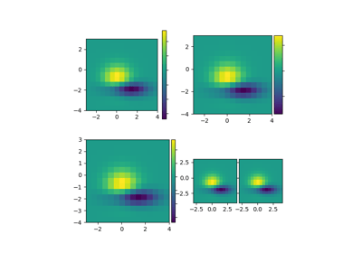

[Demo Axes Divider](https://matplotlib.org/3.1.1/gallery/axes_grid1/demo_axes_divider.html#sphx-glr-gallery-axes-grid1-demo-axes-divider-py)

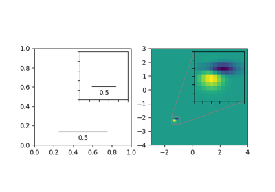

[Inset Locator Demo2](https://matplotlib.org/3.1.1/gallery/axes_grid1/inset_locator_demo2.html#sphx-glr-gallery-axes-grid1-inset-locator-demo2-py)

[figure not shown]

[Interactive functions](https://matplotlib.org/3.1.1/gallery/event_handling/ginput_manual_clabel_sgskip.html#sphx-glr-gallery-event-handling-ginput-manual-clabel-sgskip-py)

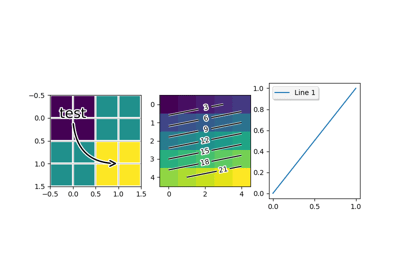

[Patheffect Demo](https://matplotlib.org/3.1.1/gallery/misc/patheffect_demo.html#sphx-glr-gallery-misc-patheffect-demo-py)

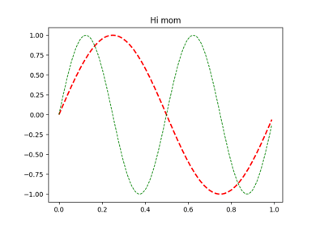

[Set And Get](https://matplotlib.org/3.1.1/gallery/misc/set_and_get.html#sphx-glr-gallery-misc-set-and-get-py)

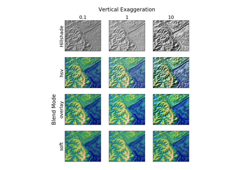

[Topographic hillshading](https://matplotlib.org/3.1.1/gallery/specialty_plots/topographic_hillshading.html#sphx-glr-gallery-specialty-plots-topographic-hillshading-py)

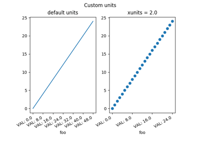

[Evans test](https://matplotlib.org/3.1.1/gallery/units/evans_test.html#sphx-glr-gallery-units-evans-test-py)

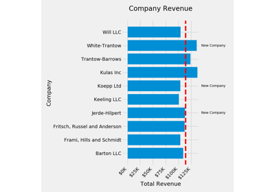

[The Lifecycle of a Plot](https://matplotlib.org/3.1.1/tutorials/introductory/lifecycle.html#sphx-glr-tutorials-introductory-lifecycle-py)